# C1380 Analysis Report

Authors

Affiliation

Sam Manski

Michigan State University, Center for Statistical Training and Consulting

Steven J. Pierce

Michigan State University, Center for Statistical Training and Consulting

## 1 Project Summary

This project aims to compare the pain management effectiveness after lumpectomy using break surgery-specific Enhanced Recovery After Surgery (ERAS) protocol with or without Liposomal Bupivacaine (Exparel). Exparel is more expensive than Bupivacaine Hydrochloride (Control). While previous studies have shown “no significant difference” between Exparel and the Control, most previous studies have performed tests for a significant difference, which does not equate to showing that the two treatments are clinically equivalent. In order to show that Exparel and the Control are clinically equivalent in terms of pain management, we perform an equivalence test procedure on the difference in patient pain scores during a postop call (approximately POD 2) and a postop visit (approximately POD 10). We a priori set an equivalence margin of 2 points on the Numeric Rating Scale (NRS) based on prior studies that set the minimum clinically important difference in this range. The equivalence tests were significant at $\alpha = 0.05$ for both the postop call and visit and we conclude that Exparel and the Control are clinically equivalent in terms of pain management after lumpectomy.

## 2 Prerequisites

This section loads necessary R packages and reads and cleans the raw project data. This section is included for reproducibility purposes.

```r
library(tidyverse)
library(gt)
library(naniar)
library(TOSTER)
library(kableExtra)
```

```r
C1380_Data <- read_csv("Data/C1380_Data_4_23_2024.csv")
#Rename variables
names(C1380_Data) <- c("Patient_ID", "Group", "Surgery_Date", "Age",
                       "Race_Ethnicity", "Hispanic_Ethnicity", "Gender",
                       "Benign_vs_Malignant", "Lymph_Node",
                       "MME_Discharge", "Chronic_Opiod", "POD_Postop_Call",
                       "Pain_Scale_Postop_Call", "POD_Postop_Visit",
                       "Pain_Scale_Postop_Visit", "Side_Effects",
                       "Postop_ER", "ER_Reason",
                       "Intraop_Toradol", "Refills_Requested")

#Set variables to factors and change levels to be more readable
C1380_Data$Group <- as.factor(C1380_Data$Group)
levels(C1380_Data$Group)[match("0=No Exparel", levels(C1380_Data$Group))]<- "Control"
levels(C1380_Data$Group)[match("1=Exparel", levels(C1380_Data$Group))]<- "Exparel"

C1380_Data$Race_Ethnicity <- as.factor(C1380_Data$Race_Ethnicity)
levels(C1380_Data$Race_Ethnicity) <- gsub("\\d=", "", levels(C1380_Data$Race_Ethnicity))

C1380_Data$Hispanic_Ethnicity <- as.factor(C1380_Data$Hispanic_Ethnicity)
levels(C1380_Data$Hispanic_Ethnicity) <- gsub("\\d=", "",
                                              levels(C1380_Data$Hispanic_Ethnicity))

C1380_Data$Gender <- as.factor(C1380_Data$Gender)
C1380_Data$Benign_vs_Malignant <- as.factor(C1380_Data$Benign_vs_Malignant)
C1380_Data$Lymph_Node <- as.factor(C1380_Data$Lymph_Node)
C1380_Data$Chronic_Opiod <- as.factor(C1380_Data$Chronic_Opiod)
levels(C1380_Data$Chronic_Opiod) <- c("No", "Yes")
C1380_Data$Intraop_Toradol <- as.factor(C1380_Data$Intraop_Toradol)
levels(C1380_Data$Intraop_Toradol) <- c("No", "Yes")
C1380_Data$Refills_Requested <- as.factor(C1380_Data$Refills_Requested)
levels(C1380_Data$Refills_Requested) <- c("No", "Yes")
C1380_Data$Postop_ER <- as.factor(C1380_Data$Postop_ER)
levels(C1380_Data$Postop_ER) <- c("No", "Yes")
C1380_Data$MME_Discharge <- as.factor(C1380_Data$MME_Discharge)

# Change "N/A" to NA and treat POD and Pain Scale variables as numeric
C1380_Data$POD_Postop_Call[which(C1380_Data$POD_Postop_Call == "N/A")] <- NA
C1380_Data$POD_Postop_Call <- as.numeric(C1380_Data$POD_Postop_Call)
C1380_Data$Pain_Scale_Postop_Call[which(C1380_Data$Pain_Scale_Postop_Call == "N/A")] <- NA
C1380_Data$Pain_Scale_Postop_Call <- as.numeric(C1380_Data$Pain_Scale_Postop_Call)

C1380_Data$POD_Postop_Visit[which(C1380_Data$POD_Postop_Visit == "N/A")] <- NA
C1380_Data$POD_Postop_Visit <- as.numeric(C1380_Data$POD_Postop_Visit)
C1380_Data$Pain_Scale_Postop_Visit[which(C1380_Data$Pain_Scale_Postop_Visit == "N/A")] <- NA
C1380_Data$Pain_Scale_Postop_Visit <- as.numeric(C1380_Data$Pain_Scale_Postop_Visit)
```

## 3 Initial Data Analysis

A key first step when performing data analysis is initial data analysis (IDA) including summarizing missing data and univariate descriptions of variables.

### 3.1 Missing Data

We first summarize the missing data for our key outcome variables (pain scale at the postop call and visit) and the POD of the call and visit in Table 1.

```r
tab1 <- C1380_Data %>%
  select(POD_Postop_Call, Pain_Scale_Postop_Call,
         POD_Postop_Visit, Pain_Scale_Postop_Visit) %>%
  miss_var_summary()%>%
 mutate(pct_miss = round(pct_miss, digits = 2),
        variable = gsub("_", " ", variable))%>%
  rename(pct_miss_all = pct_miss, n_miss_all = n_miss)

tab2 <- C1380_Data %>% group_by(Group)%>%
  select(POD_Postop_Call, Pain_Scale_Postop_Call,
         POD_Postop_Visit, Pain_Scale_Postop_Visit) %>%
  miss_var_summary() %>%
  mutate(pct_miss = round(pct_miss, digits = 2),
         variable = gsub("_", " ", variable)) %>%
  pivot_wider(names_from = Group, values_from = c(n_miss, pct_miss))

tab3 <- merge(tab1, tab2, by = "variable")
tab_out <- tab3[, c(1,2,5,4,3,7,6)]

kableExtra::kable(tab_out, col.names = c("Variable", "All", "Control",
                                      "Exparel", "All", "Control",
                                      "Exparel"),
                  row.names = FALSE)%>%
add_header_above(header = c(" " = 1, "Missing (Count)" = 3, "Missing (%)" = 3))
```

Table 1: Summary of missingness for POD and Pain Scale during postop call and visit by group.

| Variable | Missing (Count) All | Missing (Count) Control | Missing (Count) Exparel | Missing (%) All | Missing (%) Control | Missing (%) Exparel |
| --- | --- | --- | --- | --- | --- | --- |
| Pain Scale Postop Call | 23 | 8 | 15 | 30.26 | 28.57 | 31.25 |
| Pain Scale Postop Visit | 3 | 1 | 2 | 3.95 | 3.57 | 4.17 |
| POD Postop Call | 6 | 1 | 5 | 7.89 | 3.57 | 10.42 |
| POD Postop Visit | 1 | 0 | 1 | 1.32 | 0.00 | 2.08 |

### 3.2 Univariate Descriptions

We further describe the observed data through univariate descriptions.

```r
categorical_vars <- c("Race_Ethnicity", "Hispanic_Ethnicity", "Gender",
                      "Benign_vs_Malignant", "Lymph_Node", "Chronic_Opiod",
                      "Postop_ER", "Intraop_Toradol", "Refills_Requested",
                      "MME_Discharge")
numeric_vars <- c("Age", "POD_Postop_Call", "Pain_Scale_Postop_Call",
                  "POD_Postop_Visit", "Pain_Scale_Postop_Visit")
summary(C1380_Data[,categorical_vars])
```

```
                                 Race_Ethnicity Hispanic_Ethnicity    Gender
 White                                  :70     No     :72         Female:76
 Black/African American/African Diaspora: 2     Yes    : 1
 Asian/Pacific Islander                 : 2     Unknown: 3
 Unknown                                : 2
 Benign_vs_Malignant Lymph_Node Chronic_Opiod Postop_ER Intraop_Toradol
 Benign   :20        None:42    No :65        No :73    No :46
 Malignant:56        SLNB:34    Yes:11        Yes: 3    Yes:30


 Refills_Requested MME_Discharge
 No :76            0 :74
 Yes: 0            18: 1
                   30: 1
```

```r
summary(C1380_Data[,numeric_vars])
```

```
      Age        POD_Postop_Call Pain_Scale_Postop_Call POD_Postop_Visit
 Min.   :20.00   Min.   : 1.0    Min.   :0.000          Min.   : 6.000
 1st Qu.:47.75   1st Qu.: 1.0    1st Qu.:0.000          1st Qu.: 8.000
 Median :64.50   Median : 1.0    Median :2.000          Median :10.000
 Mean   :60.30   Mean   : 2.2    Mean   :1.925          Mean   : 9.867
 3rd Qu.:72.25   3rd Qu.: 3.0    3rd Qu.:3.000          3rd Qu.:11.000
 Max.   :86.00   Max.   :16.0    Max.   :8.000          Max.   :36.000
                 NA's   :6       NA's   :23             NA's   :1
 Pain_Scale_Postop_Visit
 Min.   :0.000
 1st Qu.:0.000
 Median :1.000
 Mean   :1.192
 3rd Qu.:2.000
 Max.   :8.000
 NA's   :3
```

## 4 Attrition Analysis

Due to a high degree of missingness in the primary outcomes (pain scale on postop call and visit), it is important to assess whether missingness is related to the treatment or any other variables. We summarize the results of this attrition analysis here and include the code used to generate all presented results.

We first conducted Chi Squared tests of independence to discern if treatment and missingness are independent for the pain scale responses for both the postop call and visit. Both tests were not significant at $\alpha = 0.05$ and we conclude that there is insufficient evidence to suggest missingness for pain scale scores and treatment are not independent. This means that the missingness does not vary significantly between treatment (Exparel) and control groups.

```r
C1380_Data$Missing_Call_Pain <- as.factor(ifelse(is.na(C1380_Data$Pain_Scale_Postop_Call), "Yes", "No"))
C1380_Data$Missing_Visit_Pain <- as.factor(ifelse(is.na(C1380_Data$Pain_Scale_Postop_Visit), "Yes", "No"))

chisq.test(C1380_Data$Missing_Visit_Pain, C1380_Data$Group)
```

```
    Pearson's Chi-squared test with Yates' continuity correction

data:  C1380_Data$Missing_Visit_Pain and C1380_Data$Group
X-squared = 9.0943e-31, df = 1, p-value = 1
```

```r
chisq.test(C1380_Data$Missing_Call_Pain, C1380_Data$Group)
```

```
    Pearson's Chi-squared test with Yates' continuity correction

data:  C1380_Data$Missing_Call_Pain and C1380_Data$Group
X-squared = 0, df = 1, p-value = 1
```

We do not attempt to predict missingness using Race_Ethnicity, Hispanic_Ethnicity, Refills_Requested, MME_Discharge, or Postop_ER due to a lack of variation in the data (majority of data taking the same level).

```r
call_drop_age <- glm(Missing_Call_Pain ~ Age, family = "binomial",
                     data = C1380_Data)
call_drop_age_summary <-summary(call_drop_age)
visit_drop_age <- glm(Missing_Visit_Pain ~ Age,
                      family = "binomial", data = C1380_Data)
visit_drop_age_summary <-summary(visit_drop_age)
drop_table <- data.frame(Coefficient =
                           dimnames(call_drop_age_summary$coefficients)[[1]],
                                 Estimate_C = call_drop_age_summary$coefficients[,1],
                                 P_Value_C = call_drop_age_summary$coefficients[,4],
                                  Estimate_V = visit_drop_age_summary$coefficients[,1],
                                 P_Value_V = visit_drop_age_summary$coefficients[,4])


call_drop_BvM <- glm(Missing_Call_Pain ~ Benign_vs_Malignant,
                     family = "binomial", data = C1380_Data)
call_drop_BvM_summary <-summary(call_drop_BvM)
visit_drop_BvM <- glm(Missing_Visit_Pain ~ Benign_vs_Malignant,
                      family = "binomial", data = C1380_Data)
visit_drop_BvM_summary <-summary(visit_drop_BvM)
drop_table <- rbind(drop_table,data.frame(Coefficient =
                                            dimnames(call_drop_BvM_summary$coefficients)[[1]],
                                 Estimate_C = call_drop_BvM_summary$coefficients[,1],
                                 P_Value_C = call_drop_BvM_summary$coefficients[,4],
                                  Estimate_V = visit_drop_BvM_summary$coefficients[,1],
                                 P_Value_V = visit_drop_BvM_summary$coefficients[,4]))

call_drop_Lymph_Node <- glm(Missing_Call_Pain ~ Lymph_Node,
                            family = "binomial", data = C1380_Data)
call_drop_Lymph_Node_summary <-summary(call_drop_Lymph_Node)
visit_drop_Lymph_Node <- glm(Missing_Visit_Pain ~ Lymph_Node,
                             family = "binomial", data = C1380_Data)
visit_drop_Lymph_Node_summary <-summary(visit_drop_Lymph_Node)
drop_table <- rbind(drop_table,data.frame(Coefficient = dimnames(call_drop_Lymph_Node_summary$coefficients)[[1]],
                                 Estimate_C = call_drop_Lymph_Node_summary$coefficients[,1],
                                 P_Value_C = call_drop_Lymph_Node_summary$coefficients[,4],
                                  Estimate_V = visit_drop_Lymph_Node_summary$coefficients[,1],
                                 P_Value_V = visit_drop_Lymph_Node_summary$coefficients[,4]))

call_drop_Intraop_Toradol <- glm(Missing_Call_Pain ~ Intraop_Toradol,
                                 family = "binomial", data = C1380_Data)
call_drop_Intraop_Toradol_summary <-summary(call_drop_Intraop_Toradol)
visit_drop_Intraop_Toradol <- glm(Missing_Visit_Pain ~ Intraop_Toradol,
                                  family = "binomial", data = C1380_Data)
visit_drop_Intraop_Toradol_summary <-summary(visit_drop_Intraop_Toradol)
drop_table <- rbind(drop_table,data.frame(Coefficient = dimnames(call_drop_Intraop_Toradol_summary$coefficients)[[1]],
                                 Estimate_C = call_drop_Intraop_Toradol_summary$coefficients[,1],
                                 P_Value_C = call_drop_Intraop_Toradol_summary$coefficients[,4],
                                  Estimate_V = visit_drop_Intraop_Toradol_summary$coefficients[,1],
                                 P_Value_V = visit_drop_Intraop_Toradol_summary$coefficients[,4]))

call_drop_Chronic_Opiod <- glm(Missing_Call_Pain ~ Chronic_Opiod,
                               family = "binomial", data = C1380_Data)
call_drop_Chronic_Opiod_summary <-summary(call_drop_Chronic_Opiod)
visit_drop_Chronic_Opiod <- glm(Missing_Visit_Pain ~ Chronic_Opiod,
                                family = "binomial", data = C1380_Data)
visit_drop_Chronic_Opiod_summary <-summary(visit_drop_Chronic_Opiod)
drop_table <- rbind(drop_table,data.frame(Coefficient =
                                            dimnames(call_drop_Chronic_Opiod_summary$coefficients)[[1]],
                                 Estimate_C = call_drop_Chronic_Opiod_summary$coefficients[,1],
                                 P_Value_C = call_drop_Chronic_Opiod_summary$coefficients[,4],
                                  Estimate_V = visit_drop_Chronic_Opiod_summary$coefficients[,1],
                                 P_Value_V = visit_drop_Chronic_Opiod_summary$coefficients[,4]))

call_drop_Missing_Visit_Pain <- glm(Missing_Call_Pain ~ Missing_Visit_Pain,
                                    family = "binomial", data = C1380_Data)
call_drop_Missing_Visit_Pain_summary <-summary(call_drop_Missing_Visit_Pain)
visit_drop_Missing_Call_Pain <- glm(Missing_Visit_Pain ~ Missing_Call_Pain,
                                    family = "binomial", data = C1380_Data)
visit_drop_Missing_Call_Pain_summary <-summary(visit_drop_Missing_Call_Pain)
drop_table <- rbind(drop_table,data.frame(Coefficient = c("(Intercept)", "Missing_Other_PainYes"),
                                 Estimate_C = call_drop_Missing_Visit_Pain_summary$coefficients[,1],
                                 P_Value_C = call_drop_Missing_Visit_Pain_summary$coefficients[,4],
                                  Estimate_V = visit_drop_Missing_Call_Pain_summary$coefficients[,1],
                                 P_Value_V = visit_drop_Missing_Call_Pain_summary$coefficients[,4]))

kableExtra::kable(drop_table, row.names = FALSE,
                  col.names = c("Coefficient", "Estimate", "P-Value",
                                "Estimate", "P-Value")) %>%
add_header_above(header = c(" " = 1, "Missing Call Pain Score"=2,
                            "Missing Visit Pain Score" = 2))%>%
  pack_rows("Age", 1,2) %>%
  pack_rows("Benign Vs Malignant (Reference Level = Benign)", 3,4)%>%
  pack_rows("Lymph Node (Reference Level = None)", 5,6)%>%
  pack_rows("Intraop Toradol (Reference Level = No)", 7,8)%>%
  pack_rows("Chronic Opiod (Reference Level = No)", 9,10)%>%
  pack_rows("Missing Other Pain Score (Reference Level = No)", 11,12)
```

Table 2: Summary of logistic regression results to predict missing call/ visit pain scores from other observed variables.

| Coefficient | Missing Call Pain Score Estimate | Missing Call Pain Score P-Value | Missing Visit Pain Score Estimate | Missing Visit Pain Score P-Value |
| --- | --- | --- | --- | --- |
| **Age** |  |  |  |  |
| (Intercept) | -0.4074696 | 0.6722866 | -0.7690171 | 0.6630145 |
| Age | -0.0071271 | 0.6478163 | -0.0443095 | 0.1927947 |
| **Benign Vs Malignant (Reference Level = Benign)** |  |  |  |  |
| (Intercept) | 0.0000000 | 1.0000000 | -2.9444390 | 0.0041062 |
| Benign_vs_MalignantMalignant | -1.1962508 | 0.0290068 | -0.3513979 | 0.7792141 |
| **Lymph Node (Reference Level = None)** |  |  |  |  |
| (Intercept) | -0.1910552 | 0.5377126 | -2.5649494 | 0.0000186 |
| Lymph_NodeSLNB | -1.8238478 | 0.0030678 | -18.0011192 | 0.9952766 |
| **Intraop Toradol (Reference Level = No)** |  |  |  |  |
| (Intercept) | -0.8266786 | 0.0098839 | -3.8066625 | 0.0001664 |
| Intraop_ToradolYes | -0.0206193 | 0.9678311 | 1.1676052 | 0.3495454 |
| **Chronic Opiod (Reference Level = No)** |  |  |  |  |
| (Intercept) | -0.7396672 | 0.0052905 | -3.0285221 | 0.0000003 |
| Chronic_OpiodYes | -0.7644102 | 0.3544502 | -16.5375464 | 0.9959306 |
| **Missing Other Pain Score (Reference Level = No)** |  |  |  |  |
| (Intercept) | -0.8407832 | 0.0009799 | -3.2386785 | 0.0000070 |
| Missing_Other_PainYes | 0.1476360 | 0.9060581 | 0.1476360 | 0.9060581 |

## 5 Equivalence Tests

Due to variation in POD of the postop call and visit, we first perform a t-test for the difference in means for POD for the postop call between treatment and control groups. We do this to ensure that the POD for the call and visit to not differ significantly between treatment and control groups, which could impact the resulting pain scores. These tests were not significant at $\alpha = 0.05$ and we conclude that there is insufficient evidence to suggest that POD of the call and visit differed between groups (see below). We further display the overall and group mean POD of the postop call and visit in the table (Table 3) below.

```r
t.test(POD_Postop_Visit ~ Group, data = C1380_Data)
```

```
    Welch Two Sample t-test

data:  POD_Postop_Visit by Group
t = 0.08551, df = 37.44, p-value = 0.9323
alternative hypothesis: true difference in means between group Control and group Exparel is not equal to 0
95 percent confidence interval:
 -2.241014  2.438582
sample estimates:
mean in group Control mean in group Exparel
             9.928571              9.829787
```

```r
t.test(POD_Postop_Call ~ Group, data = C1380_Data)
```

```
    Welch Two Sample t-test

data:  POD_Postop_Call by Group
t = 0.21326, df = 67.806, p-value = 0.8318
alternative hypothesis: true difference in means between group Control and group Exparel is not equal to 0
95 percent confidence interval:
 -0.8062254  0.9991625
sample estimates:
mean in group Control mean in group Exparel
             2.259259              2.162791
```

```r
POD_all <- C1380_Data %>% summarize(type = "All", mean_POD_call = round(mean(POD_Postop_Call, na.rm = TRUE), digits = 2),
                                    mean_POD_visit = round(mean(POD_Postop_Visit,
                                                                na.rm = TRUE), digits = 2))
POD_exp <- C1380_Data %>% filter(Group == "Exparel") %>%
  summarize(type = "Exparel", mean_POD_call = round(mean(POD_Postop_Call,
                                                         na.rm = TRUE), digits = 2),
            mean_POD_visit = round(mean(POD_Postop_Visit,
                                        na.rm = TRUE), digits = 2))
POD_control <- C1380_Data %>% filter(Group == "Control") %>%
  summarize(type = "Control", mean_POD_call = round(mean(POD_Postop_Call,
                                                         na.rm = TRUE), digits = 2),
            mean_POD_visit = round(mean(POD_Postop_Visit,
                                        na.rm = TRUE), digits = 2))

POD_summary <- rbind(POD_all, POD_exp, POD_control)
kableExtra::kable(POD_summary, col.names = c("Group", "Mean POD Call",
                                             "Mean POD Visit"))
```

Table 3: Summary of mean POD for postop call and visit by group.

| Group | Mean POD Call | Mean POD Visit |
| --- | --- | --- |
| All | 2.20 | 9.87 |
| Exparel | 2.16 | 9.83 |
| Control | 2.26 | 9.93 |

After confirming that the POD for the call and visit are comparable between groups, we perform the intended equivalence tests. The hypotheses for these equivalence tests are

$H_0$: Mean pain score during the Postop Call for the Exparel and Control groups differ beyond a clinically relevant margin.

$H_1$: Mean pain score during the Postop Call for the Exparel and Control groups are clinically equivalent.

and

$H_0$: Mean pain score during the Postop Visit for the Exparel and Control groups differ beyond a clinically relevant margin.

$H_1$: Mean pain score during the Postop Visit for the Exparel and Control groups are clinically equivalent.

We use a margin of equivalence of 2 points and $\alpha = 0.05$ to perform the two-sided equivalence tests. We present groupwise mean and standard deviation for pain scale (Table 4) and the results of these tests (Table 5) below.

```r
Pain_Scale_all <- C1380_Data %>% summarize(type = "All",
                                           mean_Pain_Scale_call = round(mean(Pain_Scale_Postop_Call, na.rm = TRUE), digits = 2),
            sd_Pain_Scale_call = round(sd(Pain_Scale_Postop_Call, na.rm = TRUE), digits = 2),
            mean_Pain_Scale_visit = round(mean(Pain_Scale_Postop_Visit, na.rm = TRUE), digits = 2),
            sd_Pain_Scale_visit = round(sd(Pain_Scale_Postop_Visit, na.rm = TRUE), digits = 2))
Pain_Scale_exp <- C1380_Data %>% filter(Group == "Exparel") %>%
  summarize(type = "Exparel", mean_Pain_Scale_call = round(mean(Pain_Scale_Postop_Call, na.rm = TRUE), digits = 2),
            sd_Pain_Scale_call = round(sd(Pain_Scale_Postop_Call, na.rm = TRUE), digits = 2),
            mean_Pain_Scale_visit = round(mean(Pain_Scale_Postop_Visit, na.rm = TRUE), digits = 2),
            sd_Pain_Scale_visit = round(sd(Pain_Scale_Postop_Visit, na.rm = TRUE), digits = 2))
Pain_Scale_control <- C1380_Data %>% filter(Group == "Control") %>%
  summarize(type = "Control",
            mean_Pain_Scale_call = round(mean(Pain_Scale_Postop_Call, na.rm = TRUE), digits = 2),
            sd_Pain_Scale_call = round(sd(Pain_Scale_Postop_Call, na.rm = TRUE), digits = 2),
            mean_Pain_Scale_visit = round(mean(Pain_Scale_Postop_Visit, na.rm = TRUE), digits = 2),
            sd_Pain_Scale_visit = round(sd(Pain_Scale_Postop_Visit, na.rm = TRUE), digits = 2))

Pain_Scale_summary <- rbind(Pain_Scale_all, Pain_Scale_exp, Pain_Scale_control)

kableExtra::kable(Pain_Scale_summary, col.names = c("Group", "Mean Pain Scale Call",
                                                    "SD Pain Scale Call",
                                             "Mean Pain Scale Visit",
                                             "SD Pain Scale Visit"))
```

Table 4: Pain Scale Summary

| Group | Mean Pain Scale Call | SD Pain Scale Call | Mean Pain Scale Visit | SD Pain Scale Visit |
| --- | --- | --- | --- | --- |
| All | 1.92 | 2.12 | 1.19 | 1.69 |
| Exparel | 1.94 | 2.30 | 1.28 | 1.61 |
| Control | 1.90 | 1.83 | 1.04 | 1.83 |

```r
visit_test1 <- t_TOST(formula = Pain_Scale_Postop_Visit ~ Group,
                      data = C1380_Data, eqb = 2, hypothesis = "EQU")

call_test1 <- t_TOST(formula = Pain_Scale_Postop_Call ~ Group,
                     data = C1380_Data, eqb = 2, hypothesis = "EQU")


results_table <- data.frame(t = c(3.42, 4.13), p = c("<0.001", "<0.001"),
                            est1 = c(-0.039, -0.246), CI1 = c("[-1.001, 0.923]", "[-0.958, 0.467]"),
                            est2 = c(-0.019, -0.141), CI2 = c("[-0.465, 0.428]", "[-0.541, 0.261]"))
rownames(results_table) = c("Postop Call", "Postop Visit")
kableExtra::kable(results_table, col.names = c("Test Statistic (t)", "P-value",
                  "Estimate", "90%CI", "Estimate", "90% CI"), row.names = TRUE)%>%
add_header_above(header = c(" " = 1, "Equivalence Test"=2, "Raw Mean Pain Score Difference" = 2, "Effect Size (Hedges's g)" = 2))
```

Table 5: Equivalence test results comparing pain score at postop call and visit between Exparel and Control. Results include the t test statistic and p-value for each test along with estimates and 90% confidence intervals for the mean difference in pain between the Exparel and Control groups both on the raw pain scale and adjusted Hedges’s g effect size scale.

|  | Equivalence Test Test Statistic (t) | Equivalence Test P-value | Raw Mean Pain Score Difference Estimate | Raw Mean Pain Score Difference 90%CI | Effect Size (Hedges's g) Estimate | Effect Size (Hedges's g) 90% CI |
| --- | --- | --- | --- | --- | --- | --- |
| Postop Call | 3.42 | <0.001 | -0.039 | [-1.001, 0.923] | -0.019 | [-0.465, 0.428] |
| Postop Visit | 4.13 | <0.001 | -0.246 | [-0.958, 0.467] | -0.141 | [-0.541, 0.261] |

We can visualize these results by plotting together the expected distribution of the mean difference and effect size, the confidence interval, and the equivalence bounds (Figure 1, Figure 2, Figure 3 and Figure 4). We see that in all cases, the point estimate for the difference in means is near zero and the 90% and 95% confidence intervals are well within the equivalence bounds.

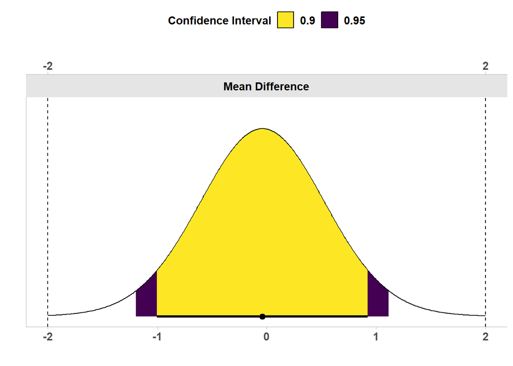

Figure 1: Density plots with 90% and 95% intervals for the mean difference in pain at the postop call on raw pain score scale.

```r
plot(call_test1, type = "cd", ci_shades = c(0.9, 0.95), estimates = "raw")
```

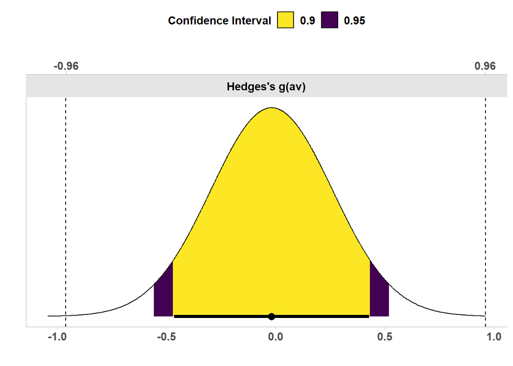

Figure 2: Density plots with 90% and 95% intervals for the mean difference in pain at the postop call on a standardized scale (Hedges’s g).

```r
plot(call_test1, type = "cd", ci_shades = c(0.9, 0.95), estimates = "SMD")
```

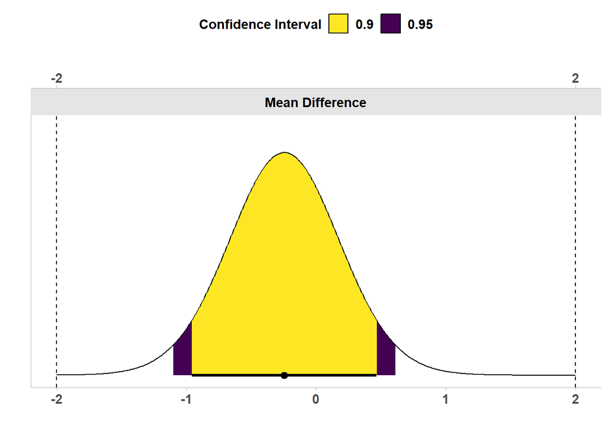

Figure 3: Density plots with 90% and 95% intervals for the mean difference in pain at the postop visit on raw pain score scale.

```r
plot(visit_test1, type = "cd", ci_shades = c(0.9, 0.95), estimates = "raw")
```

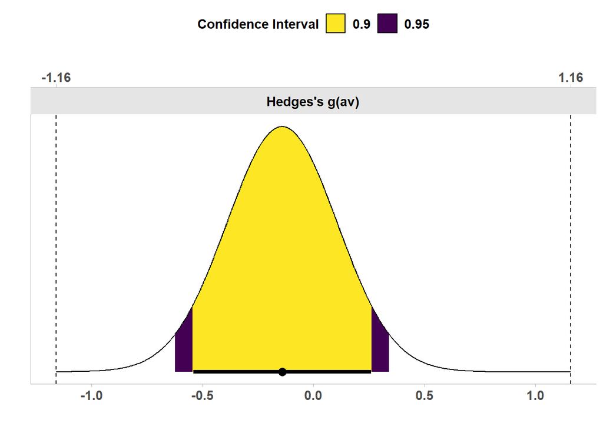

Figure 4: Density plots with 90% and 95% intervals for the mean difference in pain at the postop visit on a standardized scale (Hedges’s g).

```r
plot(visit_test1, type = "cd", ci_shades = c(0.9, 0.95), estimates = "SMD")
```